# How Americans Like Their Steak

John Cruz

2023-01-27

## Overview

Walt Hickey from FiveThirtyEight collected data from people within the United States to see if a risk-averse person would be more likely to order a steak well done. They found no evidence a person that was a higher risk taker would prefer their steaks rare.

[‘FiveThirtyEight Article’](https://fivethirtyeight.com/features/how-americans-like-their-steak/)

[‘Data Source’](https://raw.githubusercontent.com/fivethirtyeight/data/master/steak-survey/steak-risk-survey.csv)

## Required libraries

```r
library(pander)
library(tidyverse)
library(pollster)
```

## Data Dictionary

The original data set columns included the full questions asked. They will be renamed with keywords for ease:

| Keyword | Original Column |
| --- | --- |
| id | RespondentID |
| lottery_pick | Consider the following hypothetical situations: In **Lottery A**, you have a 50% chance of success, with a payout of $100. In **Lottery B**, you have a 90% chance of success, with a payout of $20. Ass… |
| smoker | Do you ever smoke cigarettes? |
| alcohol | Do you ever drink alcohol? |
| gamble | Do you ever gamble? |
| skydiving | Have you ever been skydiving? |
| speeding | Do you ever drive above the speed limit? |
| cheated | Have you ever cheated on your significant other? |
| eat_steak | Do you eat steak? |
| doneness | How do you like your steak prepared? |
| gender | Gender |
| age_group | Age |
| income_level | Household Income |
| education_level | Education |
| us_region | Location (Census Region) |

## Data Preparation

Import data from GitHub and rename columns

```r
new_colnames <- c('id', 'lottery_pick', 'smoker', 'alcohol', 'gamble', 'skydiving', 'speeding', 'cheated', 'eat_steak', 'doneness', 'gender', 'age_group', 'income_level', 'education_level', 'us_region')

steak_survey <- read.csv('https://raw.githubusercontent.com/fivethirtyeight/data/master/steak-survey/steak-risk-survey.csv', col.names = new_colnames)
```

View first few rows within the data frame.

```r
knitr::kable(head(steak_survey, 5))
```

| id | lottery_pick | smoker | alcohol | gamble | skydiving | speeding | cheated | eat_steak | doneness | gender | age_group | income_level | education_level | us_region |
| --- | --- | --- | --- | --- | --- | --- | --- | --- | --- | --- | --- | --- | --- | --- |
| NA | Response | Response | Response | Response | Response | Response | Response | Response | Response | Response | Response | Response | Response | Response |
| 3237565956 | Lottery B |  |  |  |  |  |  |  |  |  |  |  |  |  |
| 3234982343 | Lottery A | No | Yes | No | No | No | No | Yes | Medium rare | Male | > 60 | $50,000 - $99,999 | Some college or Associate degree | East North Central |
| 3234973379 | Lottery A | No | Yes | Yes | No | Yes | Yes | Yes | Rare | Male | > 60 | $150,000+ | Graduate degree | South Atlantic |
| 3234972383 | Lottery B | Yes | Yes | Yes | No | Yes | Yes | Yes | Medium | Male | > 60 | $50,000 - $99,999 | Bachelor degree | New England |

Remove data that is explicitly NA from the *id* column and people who do not eat steak. Subset data to focus on risks and their region.

```r
steak_survey <- steak_survey %>%
  drop_na(id)
```

```r
subset_cols <- c('smoker', 'alcohol', 'gamble', 'skydiving', 'speeding', 'cheated', 'doneness', 'us_region')
risks <- steak_survey %>%
  select(all_of(subset_cols))
```

```r
non_null_risks <- risks %>%
  filter(across(all_of(subset_cols), ~ .x != ''))

knitr::kable(head(non_null_risks, 5))
```

| smoker | alcohol | gamble | skydiving | speeding | cheated | doneness | us_region |
| --- | --- | --- | --- | --- | --- | --- | --- |
| No | Yes | No | No | No | No | Medium rare | East North Central |
| No | Yes | Yes | No | Yes | Yes | Rare | South Atlantic |
| Yes | Yes | Yes | No | Yes | Yes | Medium | New England |
| No | Yes | No | No | Yes | Yes | Medium | Middle Atlantic |
| No | No | No | No | Yes | No | Medium rare | West South Central |

## Findings

We can see that most individuals prefer Medium and Medium Rare cooking temperatures for their steaks.

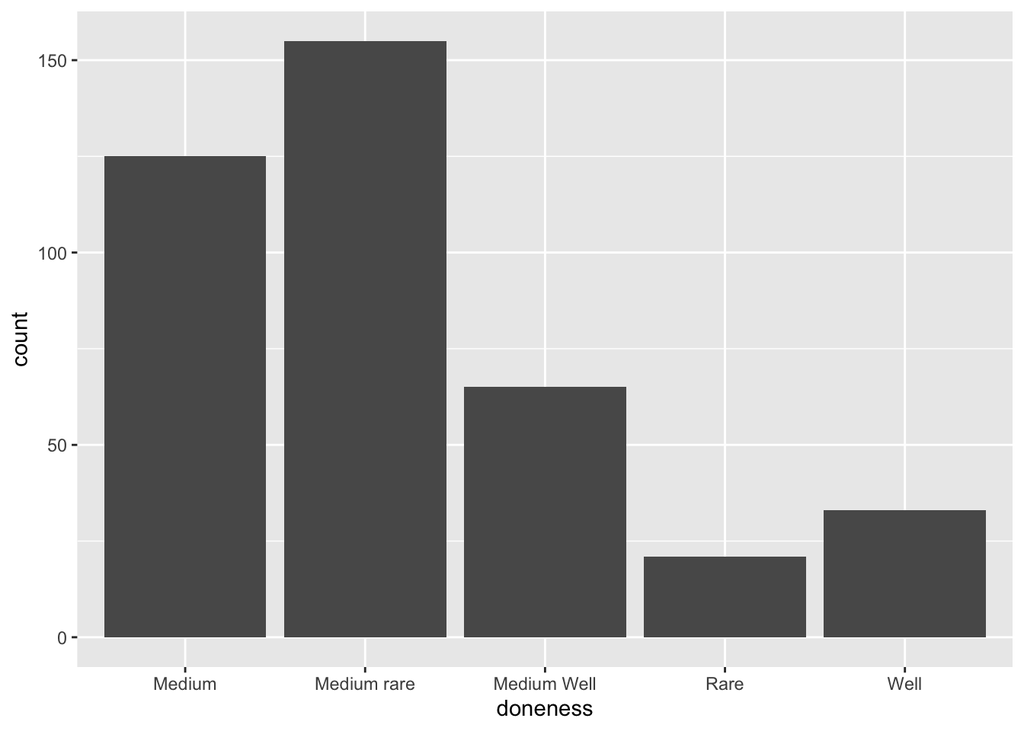

```r
ggplot(data = non_null_risks) +
  geom_bar(aes(doneness))
```

Calculate total risks taken by each individual.

```r
non_null_risks[non_null_risks=='Yes'] <- 1
non_null_risks[non_null_risks=='No'] <- 0

change_type <- c('smoker', 'alcohol', 'gamble', 'skydiving', 'speeding', 'cheated')

non_null_risks <- non_null_risks %>%
  mutate_at(change_type, as.integer)

non_null_risks$doneness <- factor(non_null_risks$doneness, levels = c('Rare', 'Medium rare', 'Medium', 'Medium Well', 'Well'))

non_null_risks <- non_null_risks %>%
  mutate(total_risks = smoker + alcohol + gamble + skydiving + speeding + cheated)
```

Using a crosstab view, we can determine how people like their steak within each region

```r
knitr::kable(crosstab(non_null_risks, x = us_region, y = doneness, weight = total_risks))
```

| us_region | Rare | Medium rare | Medium | Medium Well | Well | n |
| --- | --- | --- | --- | --- | --- | --- |
| East North Central | 0.000000 | 40.36145 | 33.73494 | 15.662651 | 10.240964 | 166 |
| East South Central | 0.000000 | 54.34783 | 23.91304 | 6.521739 | 15.217391 | 46 |
| Middle Atlantic | 11.510791 | 20.14388 | 36.69065 | 22.302158 | 9.352518 | 139 |
| Mountain | 0.000000 | 28.20513 | 39.74359 | 17.948718 | 14.102564 | 78 |
| New England | 5.333333 | 44.00000 | 34.66667 | 12.000000 | 4.000000 | 75 |
| Pacific | 8.510638 | 34.57447 | 38.82979 | 10.106383 | 7.978723 | 188 |
| South Atlantic | 6.666667 | 38.46154 | 26.66667 | 23.076923 | 5.128205 | 195 |
| West North Central | 11.578947 | 46.31579 | 29.47368 | 12.631579 | 0.000000 | 95 |
| West South Central | 0.000000 | 51.66667 | 26.66667 | 13.333333 | 8.333333 | 60 |

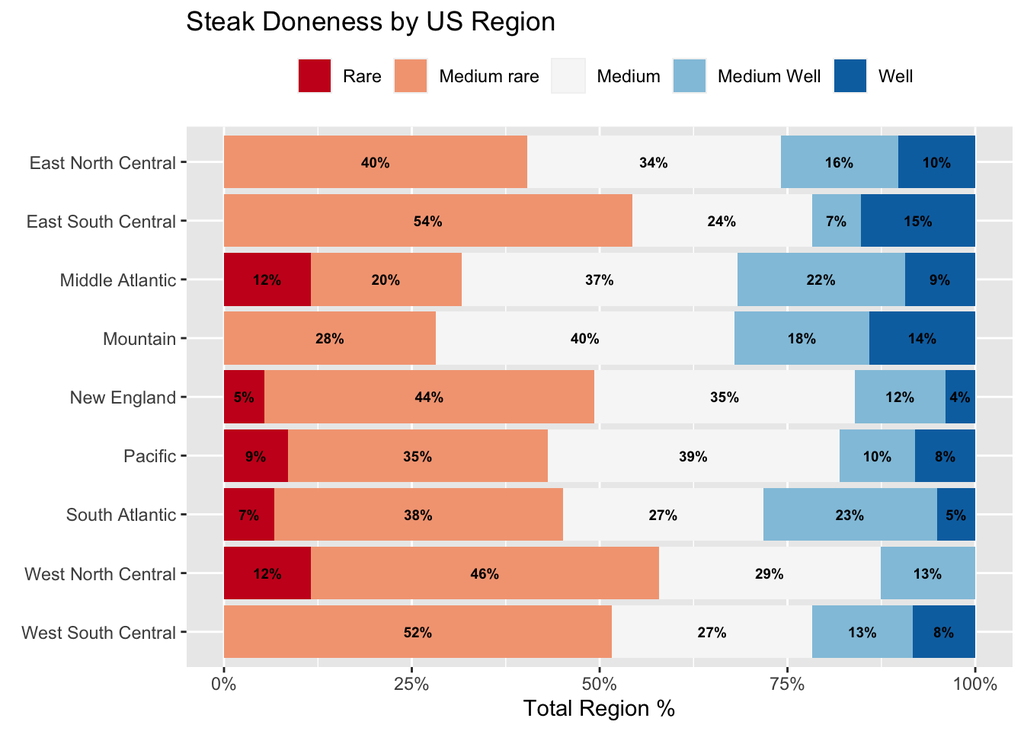

```r
grouped <- crosstab(non_null_risks, x = us_region, y = doneness, weight = total_risks, format = 'long')

grouped %>%
  ggplot(aes(x = pct, y = us_region, fill = doneness)) +
  geom_bar(stat = 'identity', position = position_fill(reverse = TRUE)) +
  xlab("Total Region %") +
  ylab(element_blank()) +
  geom_text(aes(label = paste0(round(pct, 0), '%')), position = position_fill(reverse = TRUE, vjust = 0.5), size = 2.5, color = 'black', fontface = 'bold') +
  scale_x_continuous(labels = scales::percent) +
 theme(legend.position = "top", legend.title = element_blank()) +
  labs(title = 'Steak Doneness by US Region') +
  scale_y_discrete(limits=rev) +
  scale_fill_brewer(palette="RdBu")
```

Surprisingly, not every region is represented by people who prefer their steaks rare.

## Recommendations

Given how the survey was taken, more information would be beneficial to help determine riskiness. Each question only offered the options of Yes/No, however, the degree of risk may vary based on frequency. A person who drinks alcohol, may drink a few glasses per week, but another person may drink several per day. The survey is also at risk of self-selection bias and does not account for random sampling. Lastly, are certain race/religions more prone to how they like to eat steak?